# eda_result2

```python
import numpy as np
import pandas as pd
import matplotlib.pyplot as plt
import seaborn as sns

%matplotlib inline
```

```python
hotel = pd.read_csv("/Users/oyutaeg/Desktop/data/hotel_bookings.csv")
hotel.drop('company', axis='columns', inplace=True)
```

### customer_type에 대한 예약 취소율 시각화

```python
df1 = hotel.groupby("customer_type")['is_canceled'].describe()
df1.head()
```

| customer_type | count | mean | std | min | 25% | 50% | 75% | max |
| --- | --- | --- | --- | --- | --- | --- | --- | --- |
| Contract | 4076.0 | 0.309617 | 0.462393 | 0.0 | 0.0 | 0.0 | 1.0 | 1.0 |
| Group | 577.0 | 0.102253 | 0.303244 | 0.0 | 0.0 | 0.0 | 0.0 | 1.0 |
| Transient | 89613.0 | 0.407463 | 0.491365 | 0.0 | 0.0 | 0.0 | 1.0 | 1.0 |
| Transient-Party | 25124.0 | 0.254299 | 0.435475 | 0.0 | 0.0 | 0.0 | 1.0 | 1.0 |

### 시각화 결과 customer_type에 따른 예약 취소율이 확연이 차이가 나는 모습을 보실수 있습니다.

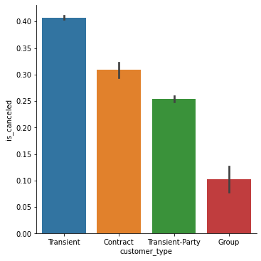

```python
sns.catplot(x="customer_type", y="is_canceled", kind="bar", data=hotel)
plt.show()
```

### deposit_type에 따른 호텔 예약 취소율 시각화

```python
df2 = hotel.groupby("deposit_type")['is_canceled'].describe()
df2
```

| deposit_type | count | mean | std | min | 25% | 50% | 75% | max |
| --- | --- | --- | --- | --- | --- | --- | --- | --- |
| No Deposit | 104641.0 | 0.283770 | 0.450829 | 0.0 | 0.0 | 0.0 | 1.0 | 1.0 |
| Non Refund | 14587.0 | 0.993624 | 0.079595 | 0.0 | 1.0 | 1.0 | 1.0 | 1.0 |
| Refundable | 162.0 | 0.222222 | 0.417029 | 0.0 | 0.0 | 0.0 | 0.0 | 1.0 |

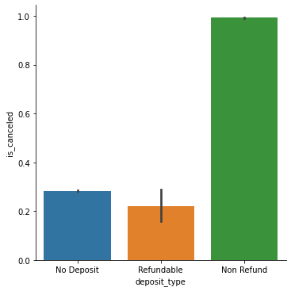

```python
sns.catplot(x="deposit_type", y="is_canceled", kind="bar", data=hotel)
plt.show()
```

### deposit_type에 따른 호텔 예약 취소율 시각화 결론 (해당 가설은 폐기)

해당 그래프는 각각 보증금이 없는 타입, 환불이 가능한 타입, 환불이 불가능한 타입에 대한 예약 취소율 시각화 그래프입니다. 해당 데이터 분석 결과는 아주 명확하게 환불이 불가능한 유형의 고객이 압도적인 비율의 예약 취소율을 보여주고 있습니다. 하지만 이것은 상식적으로 말이 안되는데 애초에 환불이 불가능하다면 예약을 취소할 이유도 없습니다. (설령 그런 경우가 있다고해도 이런 결과가 나오는건 현실에서 있을 수 없습니다.)

예를들어 생각해 봅시다.내가 모자를 하나 샀는데 사이즈가 작아서 쓸 수 없다고하면 당연히 환불을 요청할것이고 만약 환불요청이 거절당한다면 친구나 동생한테 주거나 차라리 버리면 버렸지 굳이 모자를 산 가게에 가서 모자를 돌려주지 않을것입니다. 따라서 이 분석에 대해서 처음엔 데이터 분석에서 오류가 있거나 아니면 저의 영단어 해석에 오해가 있나 싶어 수십번을 찾아보고 다시 데이터 분석을 돌려봐도 역시 데이터 분석엔 틀린게 없었고 단어의 뜻에도 오해가 없었다는것을 확인하였습니다. 따라서 이에 대한 문제를 해결하기 위해 캐글에 다른 데이터 분석을 찾아본 결과 라벨링에 오류가 있다는 결론을 내렸습니다.

공식적으로는 이 문제에 대한 공신력있는 답변은 찾지못하였지만, 몇몇 데이터 분석가들의 의견을 종합해본 결과 제가 내린 결론은 이렇습니다. "해당 데이터는 애초에 환불이 불가능한 타입에 예약이 있었던것이 아니라 어떠한 이유로 환불이 불가능해진 고객에 대해서 환불이 불가능한 유형 이라는 라벨링을 한것이 아닌가합니다."

따라서 해당 데이터에 대한 가설은 폐기하는것이 옳지만 그럼에도 불구하고 이 데이터를 분석에 포함시킨것은(결코 이 망할놈 때문에 삽질한 시간이 아까워서가 아니라) 해당 오류로 인해 데이터 분석을 하다보면 많은 오류와 편향에 부딪힐 수 있다는 교훈을 얻었다고 생각하여 포함시켜 보았습니다.